# IMT 573 - Final Examination

Points: 100

Name: Emma Harding

### Instructions

This is a take-home final examination. You may use your computer, books/articles, notes, course materials, etc., but all work must be your own! Please review the course policy on AI-based learning tools. References must be appropriately cited. Please justify your answers and show all work; a complete argument must be presented to obtain full credit. Before beginning this exam, please ensure you have access to data programming environments used in the course; this can be on your own personal computer or on shared infrastructure hosted by the university.

1. Download the exam template notebook file from Canvas. Open exam notebook and supply your solutions to the exam by editing the notebook.
2. Be sure the exam contains your full name.
3. Be sure to include well-documented (e.g. commented) code chucks, figures, and clearly written text chunk explanations as necessary. Any figures should be clearly labeled and appropriately referenced within the text. Be sure that each visualization adds value to your written explanation; avoid redundancy -- you do not need four different visualizations of the same pattern.
4. **Collaboration is not allowed on this exam. You may only speak with the course instructor about this material.**
5. All materials and resources that you use (with the exception of lecture slides) must be appropriately referenced within your assignment.
6. Remember partial credit will be awarded for each question for which a serious attempt at finding an answer has been shown. Students are **strongly** encouraged to attempt each question and to document their reasoning process even if they cannot find the correct answer. If you would like to include code to show this process, but it does not run without errors, you can do so by commenting out that code.
7. When you have completed the assignment and have **checked** that your code both runs in the Console and compiles correctly rename the file to `YourLastName_YourFirstName.ipynb`, and submit BOTH your HTML and notebook files on Canvas.

### Statement of Compliance

You **must** include the a "signed" Statement of Compliance in your submission. The Compliance Statement is found below. You must include this text, word-for-word, in your final exam submission. Adding your name indicates you have read the statement and agree to its terms. Failure to do so will result in your exam **not** being accepted.

**Statement of Compliance**

I affirm that I have had no conversation regarding this exam with any persons other than the instructor. Further, I certify that the attached work represents my own thinking. Any information, concepts, or words that originate from other sources are cited in accordance with University of Washington guidelines as published in the Academic Code (available on the course website). I am aware of the serious consequences that result from improper discussions with others or from the improper citation of work that is not my own.

(Emma Harding)

(11/30/2025)

For this assignment, you'll need (at least) the following packages. If the package does not load, be sure it is properly installed.

```python
import pandas as pd
import numpy as np
import matplotlib.pyplot as plt
import seaborn as sns
import statsmodels.api as sm
```

### Problem 1

Points: 20

In this problem we will use data on infidelity, known as the Fair's Affairs dataset. The `Affairs` dataset is available as part of the `datasets` package in`statsmodels`. This data comes from a survey conducted by Psychology Today in 1969, see Greene (2003) and Fair (1978) for more information.

(a) Describe the participants. Use descriptive, summarization, and exploratory techniques to describe the participants in the study. Tell us the average/mean of children count ? What is the average age of respondents? In your response comment on any ethical and privacy concerns you have with this dataset.

```python
affairs = sm.datasets.fair.load_pandas().data
print(sm.datasets.fair.NOTE)
```

```
::

    Number of observations: 6366
    Number of variables: 9
    Variable name definitions:

        rate_marriage   : How rate marriage, 1 = very poor, 2 = poor, 3 = fair,
                        4 = good, 5 = very good
        age             : Age
        yrs_married     : No. years married. Interval approximations. See
                        original paper for detailed explanation.
        children        : No. children
        religious       : How relgious, 1 = not, 2 = mildly, 3 = fairly,
                        4 = strongly
        educ            : Level of education, 9 = grade school, 12 = high
                        school, 14 = some college, 16 = college graduate,
                        17 = some graduate school, 20 = advanced degree
        occupation      : 1 = student, 2 = farming, agriculture; semi-skilled,
                        or unskilled worker; 3 = white-colloar; 4 = teacher
                        counselor social worker, nurse; artist, writers;
                        technician, skilled worker, 5 = managerial,
                        administrative, business, 6 = professional with
                        advanced degree
        occupation_husb : Husband's occupation. Same as occupation.
        affairs         : measure of time spent in extramarital affairs

    See the original paper for more details.
```

```python
affairs.head()
```

|  | rate_marriage | age | yrs_married | children | religious | educ | occupation | occupation_husb | affairs |
| --- | --- | --- | --- | --- | --- | --- | --- | --- | --- |
| 0 | 3.0 | 32.0 | 9.0 | 3.0 | 3.0 | 17.0 | 2.0 | 5.0 | 0.111111 |
| 1 | 3.0 | 27.0 | 13.0 | 3.0 | 1.0 | 14.0 | 3.0 | 4.0 | 3.230769 |
| 2 | 4.0 | 22.0 | 2.5 | 0.0 | 1.0 | 16.0 | 3.0 | 5.0 | 1.400000 |
| 3 | 4.0 | 37.0 | 16.5 | 4.0 | 3.0 | 16.0 | 5.0 | 5.0 | 0.727273 |
| 4 | 5.0 | 27.0 | 9.0 | 1.0 | 1.0 | 14.0 | 3.0 | 4.0 | 4.666666 |

```python
affairs.tail()
```

|  | rate_marriage | age | yrs_married | children | religious | educ | occupation | occupation_husb | affairs |
| --- | --- | --- | --- | --- | --- | --- | --- | --- | --- |
| 6361 | 5.0 | 32.0 | 13.0 | 2.0 | 3.0 | 17.0 | 4.0 | 3.0 | 0.0 |
| 6362 | 4.0 | 32.0 | 13.0 | 1.0 | 1.0 | 16.0 | 5.0 | 5.0 | 0.0 |
| 6363 | 5.0 | 22.0 | 2.5 | 0.0 | 2.0 | 14.0 | 3.0 | 1.0 | 0.0 |
| 6364 | 5.0 | 32.0 | 6.0 | 1.0 | 3.0 | 14.0 | 3.0 | 4.0 | 0.0 |
| 6365 | 4.0 | 22.0 | 2.5 | 0.0 | 2.0 | 16.0 | 2.0 | 4.0 | 0.0 |

```python
affairs.describe()
```

|  | rate_marriage | age | yrs_married | children | religious | educ | occupation | occupation_husb | affairs |
| --- | --- | --- | --- | --- | --- | --- | --- | --- | --- |
| count | 6366.000000 | 6366.000000 | 6366.000000 | 6366.000000 | 6366.000000 | 6366.000000 | 6366.000000 | 6366.000000 | 6366.000000 |
| mean | 4.109645 | 29.082862 | 9.009425 | 1.396874 | 2.426170 | 14.209865 | 3.424128 | 3.850141 | 0.705374 |
| std | 0.961430 | 6.847882 | 7.280120 | 1.433471 | 0.878369 | 2.178003 | 0.942399 | 1.346435 | 2.203374 |
| min | 1.000000 | 17.500000 | 0.500000 | 0.000000 | 1.000000 | 9.000000 | 1.000000 | 1.000000 | 0.000000 |
| 25% | 4.000000 | 22.000000 | 2.500000 | 0.000000 | 2.000000 | 12.000000 | 3.000000 | 3.000000 | 0.000000 |
| 50% | 4.000000 | 27.000000 | 6.000000 | 1.000000 | 2.000000 | 14.000000 | 3.000000 | 4.000000 | 0.000000 |
| 75% | 5.000000 | 32.000000 | 16.500000 | 2.000000 | 3.000000 | 16.000000 | 4.000000 | 5.000000 | 0.484848 |
| max | 5.000000 | 42.000000 | 23.000000 | 5.500000 | 4.000000 | 20.000000 | 6.000000 | 6.000000 | 57.599991 |

```python
print(affairs['children'].mean())
print(affairs['children'].median())
```

```
1.3968740182218033
1.0
```

```python
print(affairs['age'].mean())
print(affairs['age'].median())
```

```
29.082862079798932
27.0
```

Ethical and privacy concerns I have with this dataset are that relationships can be nuanced and private. Cheating/affairs can be seen as a massive betreyal and grounds for divorce. Other concerns I have are that this dataset is biased because people have to volunteer this informaiton and so it probably isn't a great repersentation of the general population.

(b) Suppose we want to explore the characteristics of participants who engage in extramarital sexual intercourse (i.e. affairs). Instead of modeling the number of affairs, consider the binary outcome - had an affair versus didn't have an affair. Create a new variable to capture this response variable of interest. What might the advantages and disadvantages of this approach to modeling the data be in this context?

```python
affairs['affairs_filtered'] = [1 if x >= 1 else 0 for x in affairs['affairs']]
print(affairs['affairs_filtered'])
```

```
0       0
1       1
2       1
3       0
4       1
       ..
6361    0
6362    0
6363    0
6364    0
6365    0
Name: affairs_filtered, Length: 6366, dtype: int64
```

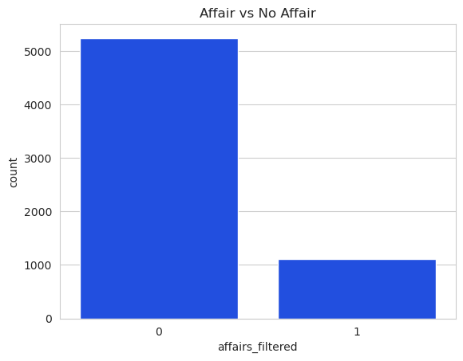

```python
sns.countplot(affairs, x="affairs_filtered")
plt.title("Affair vs No Affair")
```

Sources: https://www.geeksforgeeks.org/pandas/python-creating-a-pandas-dataframe-column-based-on-a-given-condition/

I used this source to find how to create a column based on a filter.

Sources: https://seaborn.pydata.org/generated/seaborn.countplot.html

I used this source for my count plot

(c) Use an appropriate regression model to explore the relationship between having an affair (binary) and other personal characteristics. Comment on which covariates seem to be predictive of having an affair and which do not.

```python
X = affairs[["rate_marriage", "age", "yrs_married", "children", "religious", "educ", "occupation", "occupation_husb"]]
X = sm.add_constant(X)
y = affairs["affairs_filtered"]

model = sm.Logit(y, X).fit()
print(model.summary())
```

```
Optimization terminated successfully.
         Current function value: 0.425448
         Iterations 6
                           Logit Regression Results
==============================================================================
Dep. Variable:       affairs_filtered   No. Observations:                 6366
Model:                          Logit   Df Residuals:                     6357
Method:                           MLE   Df Model:                            8
Date:                Mon, 01 Dec 2025   Pseudo R-squ.:                 0.08492
Time:                        01:31:37   Log-Likelihood:                -2708.4
converged:                       True   LL-Null:                       -2959.7
Covariance Type:            nonrobust   LLR p-value:                1.865e-103
===================================================================================
                      coef    std err          z      P>|z|      [0.025      0.975]
-----------------------------------------------------------------------------------
const               2.9926      0.345      8.680      0.000       2.317       3.668
rate_marriage      -0.6318      0.034    -18.645      0.000      -0.698      -0.565
age                -0.0469      0.012     -3.885      0.000      -0.071      -0.023
yrs_married         0.0164      0.013      1.266      0.206      -0.009       0.042
children           -0.0132      0.039     -0.335      0.738      -0.090       0.064
religious          -0.3639      0.041     -8.887      0.000      -0.444      -0.284
educ               -0.0322      0.018     -1.740      0.082      -0.068       0.004
occupation          0.1271      0.040      3.192      0.001       0.049       0.205
occupation_husb     0.0078      0.027      0.291      0.771      -0.045       0.060
===================================================================================
```

Sources:https://www.statsmodels.org/stable/generated/statsmodels.discrete.discrete_model.Logit.html

I used this source in moduel 8 for my logistic regression

What the respondants rate their marriage, age, and relegious is the most significant because the p values are the smallest.

(d) Use a model selection procedure to obtain a "best" fit model. Is the model different from the full model you fit in part (c)? Which variables are included in the "best" fit model? [Hint: stepwise selection]

```python
import sys
!{sys.executable} -m pip install mlxtend
```

```python
affairs.head()
```

|  | rate_marriage | age | yrs_married | children | religious | educ | occupation | occupation_husb | affairs | affairs_filtered |
| --- | --- | --- | --- | --- | --- | --- | --- | --- | --- | --- |
| 0 | 3.0 | 32.0 | 9.0 | 3.0 | 3.0 | 17.0 | 2.0 | 5.0 | 0.111111 | 0 |
| 1 | 3.0 | 27.0 | 13.0 | 3.0 | 1.0 | 14.0 | 3.0 | 4.0 | 3.230769 | 1 |
| 2 | 4.0 | 22.0 | 2.5 | 0.0 | 1.0 | 16.0 | 3.0 | 5.0 | 1.400000 | 1 |
| 3 | 4.0 | 37.0 | 16.5 | 4.0 | 3.0 | 16.0 | 5.0 | 5.0 | 0.727273 | 0 |
| 4 | 5.0 | 27.0 | 9.0 | 1.0 | 1.0 | 14.0 | 3.0 | 4.0 | 4.666666 | 1 |

```python
from mlxtend.feature_selection import SequentialFeatureSelector
X = affairs.iloc[:,0:7]
y = affairs.iloc[:,-1]
```

```python
from sklearn.model_selection import train_test_split
X_train, X_test, y_train, y_test = train_test_split(X,y,test_size=0.3,random_state=100)
```

```python
from sklearn.ensemble import RandomForestClassifier
```

```python
forward_feature_selection = SequentialFeatureSelector(RandomForestClassifier(n_jobs=-1), k_features = 7, forward = True, floating = False, verbose = 2, scoring = "accuracy", cv=5).fit(X_train, y_train)
```

```
[2025-12-01 01:31:56] Features: 1/7 -- score: 0.8276481808619327
[2025-12-01 01:32:07] Features: 2/7 -- score: 0.8298920948397779
[2025-12-01 01:32:17] Features: 3/7 -- score: 0.8276451611279713
[2025-12-01 01:32:25] Features: 4/7 -- score: 0.8206887006588051
[2025-12-01 01:32:31] Features: 5/7 -- score: 0.8144063957965303
[2025-12-01 01:32:35] Features: 6/7 -- score: 0.806551061184843
[2025-12-01 01:32:37] Features: 7/7 -- score: 0.7953302330731329
```

```python
forward_feature_selection.k_feature_idx_
```

```
(0, 1, 2, 3, 4, 5, 6)
```

```python
forward_feature_selection.k_feature_names_
```

```
('rate_marriage',
 'age',
 'yrs_married',
 'children',
 'religious',
 'educ',
 'occupation')
```

```python
forward_feature_selection.k_score_
```

```
0.7953302330731329
```

```python
pd.DataFrame.from_dict(forward_feature_selection.get_metric_dict()).T
```

|  | feature_idx | cv_scores | avg_score | feature_names | ci_bound | std_dev | std_err |
| --- | --- | --- | --- | --- | --- | --- | --- |
| 1 | (0,) | [0.827354260089686, 0.8282828282828283, 0.8282... | 0.827648 | (rate_marriage,) | 0.000672 | 0.000523 | 0.000261 |
| 2 | (0, 4) | [0.8307174887892377, 0.8361391694725028, 0.826... | 0.829892 | (rate_marriage, religious) | 0.004535 | 0.003529 | 0.001764 |
| 3 | (0, 2, 4) | [0.8408071748878924, 0.8271604938271605, 0.831... | 0.827645 | (rate_marriage, yrs_married, religious) | 0.011375 | 0.00885 | 0.004425 |
| 4 | (0, 1, 2, 4) | [0.8318385650224215, 0.8249158249158249, 0.826... | 0.820689 | (rate_marriage, age, yrs_married, religious) | 0.011614 | 0.009036 | 0.004518 |
| 5 | (0, 1, 2, 3, 4) | [0.8195067264573991, 0.8215488215488216, 0.814... | 0.814406 | (rate_marriage, age, yrs_married, children, re... | 0.008079 | 0.006285 | 0.003143 |
| 6 | (0, 1, 2, 3, 4, 6) | [0.8150224215246636, 0.8080808080808081, 0.804... | 0.806551 | (rate_marriage, age, yrs_married, children, re... | 0.00948 | 0.007376 | 0.003688 |
| 7 | (0, 1, 2, 3, 4, 5, 6) | [0.8038116591928252, 0.7934904601571269, 0.789... | 0.79533 | (rate_marriage, age, yrs_married, children, re... | 0.006192 | 0.004818 | 0.002409 |

The values featured in the best fit model are 2, which are rate_marriage and religious, I used up to 7 values and the accuracy rating just ended up going down.

Sources: https://www.youtube.com/watch?v=POCvLGRLDzM

(e) Interpret the model parameters using the model from part (d).

Using just one parameter, rate_marriage brings the score to 82.76%, adding in relegious only raises the score to 82.96%, adding in more features makes the accuracy rating go down.

```python
import random
```

```python
random_rate_marriage = np.random.randint(1, 6, size=6366)
age_mean = 29.082
yrs_married_mean = 9.009
children_mean = 1.396
religious_mean = 2.426
educ_mean = 14.209
occupation_mean = 3.424
occupation_husb_mean = 3.850
affair_likelyhood = affairs["affairs_filtered"]
affairs_test = pd.DataFrame({"rate_marriage": random_rate_marriage,"age": age_mean, "yrs_married": yrs_married_mean, "children": children_mean, "religious": religious_mean, "educ": educ_mean,"occupation": occupation_mean,"occupation_husb": occupation_husb_mean})


print(affairs_test)
```

```
      rate_marriage     age  yrs_married  children  religious    educ  \
0                 2  29.082        9.009     1.396      2.426  14.209
1                 2  29.082        9.009     1.396      2.426  14.209
2                 3  29.082        9.009     1.396      2.426  14.209
3                 1  29.082        9.009     1.396      2.426  14.209
4                 4  29.082        9.009     1.396      2.426  14.209
...             ...     ...          ...       ...        ...     ...
6361              4  29.082        9.009     1.396      2.426  14.209
6362              2  29.082        9.009     1.396      2.426  14.209
6363              1  29.082        9.009     1.396      2.426  14.209
6364              1  29.082        9.009     1.396      2.426  14.209
6365              2  29.082        9.009     1.396      2.426  14.209

      occupation  occupation_husb
0          3.424             3.85
1          3.424             3.85
2          3.424             3.85
3          3.424             3.85
4          3.424             3.85
...          ...              ...
6361       3.424             3.85
6362       3.424             3.85
6363       3.424             3.85
6364       3.424             3.85
6365       3.424             3.85

[6366 rows x 8 columns]
```

```python
from sklearn.linear_model import LogisticRegression
from sklearn.model_selection import train_test_split
from sklearn.metrics import classification_report, confusion_matrix

X1 = affairs_test[["rate_marriage","age", "yrs_married", "children", "religious", "educ", "occupation", "occupation_husb"]].values
y1 = affairs["affairs_filtered"].values

log_reg = LogisticRegression()
log_reg.fit(X1, y1)

print("Coefficients:", log_reg.coef_)
print("Intercept:", log_reg.intercept_)
```

```
Coefficients: [[ 0.00396013 -0.03889828 -0.01204988 -0.0018672  -0.00324487 -0.01900508
  -0.00457973 -0.00514952]]
Intercept: [-0.0013383]
```

Sources: logistic_regression_iris_example

(g) Reflect on your analysis in this problem. After completing all the parts of this analysis what remaining and additional ethical and privacy conerns do you have?

The only additional ethical and privacy concerns I have are that affair data is very sensitive, and I don't think people should use this data to see if their partner is going to have an affair.

### Problem 2

Points: 20

In this problem set, we will use some data from a sports context. The data is provided as part of the [Introduction to Statistial Learning with Applications in Python](https://www.statlearning.com/) textbook. It was taken from the StatLib library which is maintained at Carnegie Mellon University. The data provided is part of the data that was used in the 1988 ASA Graphics Section Poster Session. The salary data were originally from Sports Illustrated, April 20, 1987. The 1986 and career statistics were obtained from The 1987 Baseball Encyclopedia Update published by Collier Books, Macmillan Publishing Company, New York.

Following the directions below to load this data, `Hitters` directly from the `ISLP` python package. You may need to install the `ISLP` package before you can get started. In the Jupyter Hub you can open a terminal and use `pip install ISLP`. Next load the data as follows:

```python
pip install ISLP
```

[output not shown]

```python
from ISLP import load_data
Hitters = load_data('Hitters')
```

(a) Develop your own question to address in this analysis. Your question should be specific and measurable, and it should be able to be addressed through a basic analysis of the `Hitters` dataset. Hint: you will need to get to know this dataset and the variables available to formulate an appropriate question.

My question: I wonder if salary is correlated with Years, or Runs more heavily. My second question: I wonder if at bats is correlated with hits and runs.

(b) Briefly summarize the dataset, describing what data exists and its basic properties. Comment on any issues that need to be resolved before you can proceed with your analysis.

```python
Hitters.head()
```

|  | AtBat | Hits | HmRun | Runs | RBI | Walks | Years | CAtBat | CHits | CHmRun | CRuns | CRBI | CWalks | League | Division | PutOuts | Assists | Errors | Salary | NewLeague |
| --- | --- | --- | --- | --- | --- | --- | --- | --- | --- | --- | --- | --- | --- | --- | --- | --- | --- | --- | --- | --- |
| 0 | 293 | 66 | 1 | 30 | 29 | 14 | 1 | 293 | 66 | 1 | 30 | 29 | 14 | A | E | 446 | 33 | 20 | NaN | A |
| 1 | 315 | 81 | 7 | 24 | 38 | 39 | 14 | 3449 | 835 | 69 | 321 | 414 | 375 | N | W | 632 | 43 | 10 | 475.0 | N |
| 2 | 479 | 130 | 18 | 66 | 72 | 76 | 3 | 1624 | 457 | 63 | 224 | 266 | 263 | A | W | 880 | 82 | 14 | 480.0 | A |
| 3 | 496 | 141 | 20 | 65 | 78 | 37 | 11 | 5628 | 1575 | 225 | 828 | 838 | 354 | N | E | 200 | 11 | 3 | 500.0 | N |
| 4 | 321 | 87 | 10 | 39 | 42 | 30 | 2 | 396 | 101 | 12 | 48 | 46 | 33 | N | E | 805 | 40 | 4 | 91.5 | N |

```python
Hitters.tail()
```

|  | AtBat | Hits | HmRun | Runs | RBI | Walks | Years | CAtBat | CHits | CHmRun | CRuns | CRBI | CWalks | League | Division | PutOuts | Assists | Errors | Salary | NewLeague |
| --- | --- | --- | --- | --- | --- | --- | --- | --- | --- | --- | --- | --- | --- | --- | --- | --- | --- | --- | --- | --- |
| 317 | 497 | 127 | 7 | 65 | 48 | 37 | 5 | 2703 | 806 | 32 | 379 | 311 | 138 | N | E | 325 | 9 | 3 | 700.0 | N |
| 318 | 492 | 136 | 5 | 76 | 50 | 94 | 12 | 5511 | 1511 | 39 | 897 | 451 | 875 | A | E | 313 | 381 | 20 | 875.0 | A |
| 319 | 475 | 126 | 3 | 61 | 43 | 52 | 6 | 1700 | 433 | 7 | 217 | 93 | 146 | A | W | 37 | 113 | 7 | 385.0 | A |
| 320 | 573 | 144 | 9 | 85 | 60 | 78 | 8 | 3198 | 857 | 97 | 470 | 420 | 332 | A | E | 1314 | 131 | 12 | 960.0 | A |
| 321 | 631 | 170 | 9 | 77 | 44 | 31 | 11 | 4908 | 1457 | 30 | 775 | 357 | 249 | A | W | 408 | 4 | 3 | 1000.0 | A |

```python
Hitters.describe()
```

|  | AtBat | Hits | HmRun | Runs | RBI | Walks | Years | CAtBat | CHits | CHmRun | CRuns | CRBI | CWalks | PutOuts | Assists | Errors | Salary |
| --- | --- | --- | --- | --- | --- | --- | --- | --- | --- | --- | --- | --- | --- | --- | --- | --- | --- |
| count | 322.000000 | 322.000000 | 322.000000 | 322.000000 | 322.000000 | 322.000000 | 322.000000 | 322.00000 | 322.000000 | 322.000000 | 322.000000 | 322.000000 | 322.000000 | 322.000000 | 322.000000 | 322.000000 | 263.000000 |
| mean | 380.928571 | 101.024845 | 10.770186 | 50.909938 | 48.027950 | 38.742236 | 7.444099 | 2648.68323 | 717.571429 | 69.490683 | 358.795031 | 330.118012 | 260.239130 | 288.937888 | 106.913043 | 8.040373 | 535.925882 |
| std | 153.404981 | 46.454741 | 8.709037 | 26.024095 | 26.166895 | 21.639327 | 4.926087 | 2324.20587 | 654.472627 | 86.266061 | 334.105886 | 333.219617 | 267.058085 | 280.704614 | 136.854876 | 6.368359 | 451.118681 |
| min | 16.000000 | 1.000000 | 0.000000 | 0.000000 | 0.000000 | 0.000000 | 1.000000 | 19.00000 | 4.000000 | 0.000000 | 1.000000 | 0.000000 | 0.000000 | 0.000000 | 0.000000 | 0.000000 | 67.500000 |
| 25% | 255.250000 | 64.000000 | 4.000000 | 30.250000 | 28.000000 | 22.000000 | 4.000000 | 816.75000 | 209.000000 | 14.000000 | 100.250000 | 88.750000 | 67.250000 | 109.250000 | 7.000000 | 3.000000 | 190.000000 |
| 50% | 379.500000 | 96.000000 | 8.000000 | 48.000000 | 44.000000 | 35.000000 | 6.000000 | 1928.00000 | 508.000000 | 37.500000 | 247.000000 | 220.500000 | 170.500000 | 212.000000 | 39.500000 | 6.000000 | 425.000000 |
| 75% | 512.000000 | 137.000000 | 16.000000 | 69.000000 | 64.750000 | 53.000000 | 11.000000 | 3924.25000 | 1059.250000 | 90.000000 | 526.250000 | 426.250000 | 339.250000 | 325.000000 | 166.000000 | 11.000000 | 750.000000 |
| max | 687.000000 | 238.000000 | 40.000000 | 130.000000 | 121.000000 | 105.000000 | 24.000000 | 14053.00000 | 4256.000000 | 548.000000 | 2165.000000 | 1659.000000 | 1566.000000 | 1378.000000 | 492.000000 | 32.000000 | 2460.000000 |

This dataset is information about baseball players and their stats.

(c) Use the dataset to provide empirical evidence that addressed your question from (a). Discuss your results. Provide at least two visualizations to support your story.

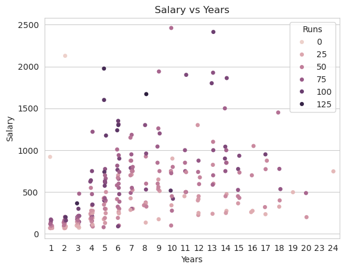

```python
sns.set_palette("bright")
sns.set_style("whitegrid")
sns.stripplot(Hitters, x="Years", y="Salary", hue="Runs")
plt.title("Salary vs Years")
plt.xlabel("Years")
plt.ylabel("Salary")
```

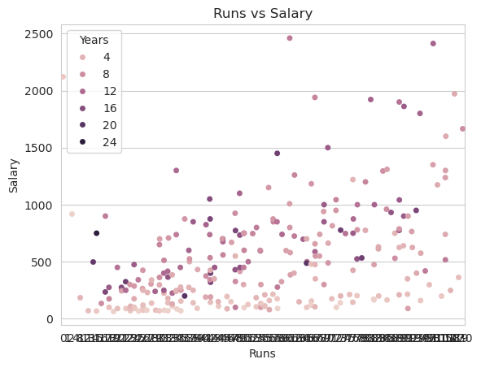

```python
sns.set_palette("bright")
sns.set_style("whitegrid")
sns.stripplot(Hitters, x="Runs", y="Salary", hue="Years")
plt.title("Runs vs Salary")
plt.xlabel("Runs")
plt.ylabel("Salary")
```

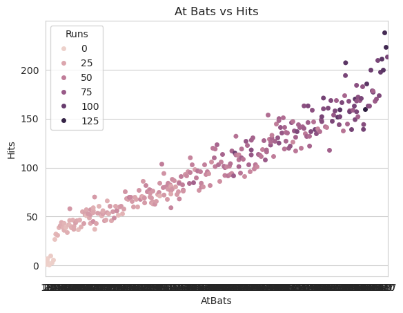

```python
sns.set_palette("bright")
sns.set_style("whitegrid")
sns.stripplot(Hitters, x="AtBat", y="Hits", hue="Runs")
plt.title("At Bats vs Hits")
plt.xlabel("AtBats")
plt.ylabel("Hits")
```

(d) Comment the questions (and answers) in this analysis. Were you able to answer all of these questions? Are all questions well defined? Is the data good enough to answer all these?

Salary is coorelated with years and runs, but appears to be more heavily coorelated with runs, so someone who hits a lot of runs but hasn't been playing for very many years would command a nice salary. My question is well defined and the data is good enough to answer my questions. At bats is correlated with hits which makes sense, the more at bats someone has the more likely they are to score a run or get a hit. My question is well defined and the data is good enough to answer my questions.

### Problem 3

Points: 20

In this problem, we will use data available in [Machine Learning with R by Brett Lantz](https://subscription.packtpub.com/search?query=machine%20learning%20r). This data was available in the public domain and a few version exist online.

The data describe individual medical costs billed by health insurance. For each observation, there is information about:

- age: age of primary beneficiary of the insurance policy
- sex: the person's sex, measured here a binary gender
- bmi: body mass index, providing an understanding of body, weights that are relatively high or low relative to height, (kg / m ^ 2)
- children: number of children/dependents covered by health insurance
- smoker: smoking status of the primary beneficiary
- region: the beneficiary's residential area in the US, northeast, southeast, southwest, northwest.
- charges: medical costs billed by health insurance

In our analysis, we will be interested in the relationship between `charges` and the individual characteristics measured.

```python
df = pd.read_csv('insurance.csv')
df.head()
```

|  | age | sex | bmi | children | smoker | region | charges |
| --- | --- | --- | --- | --- | --- | --- | --- |
| 0 | 19 | female | 27.900 | 0 | yes | southwest | 16884.92400 |
| 1 | 18 | male | 33.770 | 1 | no | southeast | 1725.55230 |
| 2 | 28 | male | 33.000 | 3 | no | southeast | 4449.46200 |
| 3 | 33 | male | 22.705 | 0 | no | northwest | 21984.47061 |
| 4 | 32 | male | 28.880 | 0 | no | northwest | 3866.85520 |

```python
df.tail()
```

|  | age | sex | bmi | children | smoker | region | charges |
| --- | --- | --- | --- | --- | --- | --- | --- |
| 1333 | 50 | male | 30.97 | 3 | no | northwest | 10600.5483 |
| 1334 | 18 | female | 31.92 | 0 | no | northeast | 2205.9808 |
| 1335 | 18 | female | 36.85 | 0 | no | southeast | 1629.8335 |
| 1336 | 21 | female | 25.80 | 0 | no | southwest | 2007.9450 |
| 1337 | 61 | female | 29.07 | 0 | yes | northwest | 29141.3603 |

```python
df.describe()
```

|  | age | bmi | children | charges |
| --- | --- | --- | --- | --- |
| count | 1338.000000 | 1338.000000 | 1338.000000 | 1338.000000 |
| mean | 39.207025 | 30.663397 | 1.094918 | 13270.422265 |
| std | 14.049960 | 6.098187 | 1.205493 | 12110.011237 |
| min | 18.000000 | 15.960000 | 0.000000 | 1121.873900 |
| 25% | 27.000000 | 26.296250 | 0.000000 | 4740.287150 |
| 50% | 39.000000 | 30.400000 | 1.000000 | 9382.033000 |
| 75% | 51.000000 | 34.693750 | 2.000000 | 16639.912515 |
| max | 64.000000 | 53.130000 | 5.000000 | 63770.428010 |

In our analysis, we will be interested in the relationship between charges and the individual characteristics measured.

(a) Examine the bivariate relationships present in the data. Briefly discuss notable results.

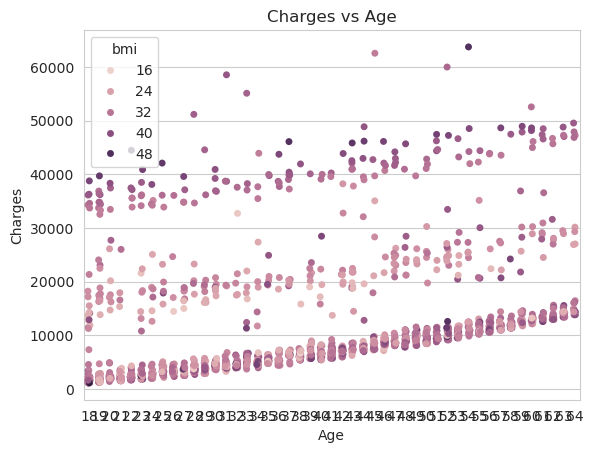

```python
sns.set_palette("bright")
sns.set_style("whitegrid")
sns.stripplot(df, x="age", y="charges", hue = "bmi")
plt.title("Charges vs Age")
plt.xlabel("Age")
plt.ylabel("Charges")
```

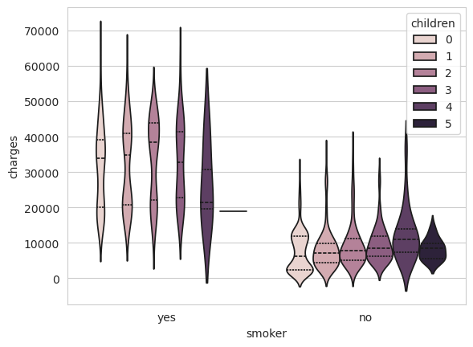

```python
sns.set_palette("bright")
sns.set_style("whitegrid")
sns.violinplot(data=df, x="smoker", y="charges",inner="quart", hue = "children")
```

[figure not shown]

```python
sns.set_palette("bright")
sns.set_style("whitegrid")
sns.violinplot(data=df, x="children", y="charges",inner="quart", hue = "smoker")
plt.title("Charges vs Children")
plt.xlabel("Age")
plt.ylabel("Charges")
```

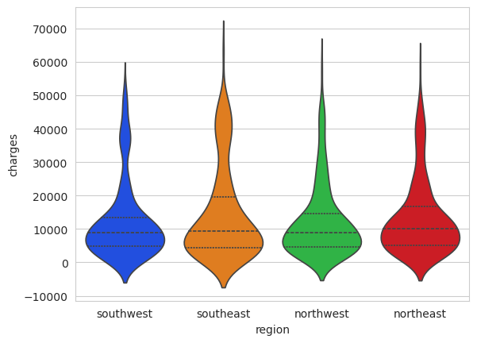

```python
sns.set_palette("bright")
sns.set_style("whitegrid")
sns.violinplot(data=df, x="region", y="charges",inner="quart", hue = "region")
```

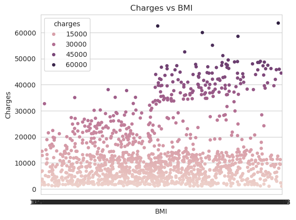

```python
sns.set_palette("bright")
sns.set_style("whitegrid")
sns.stripplot(df, x="bmi", y="charges", hue = "charges")
plt.title("Charges vs BMI")
plt.xlabel("BMI")
plt.ylabel("Charges")
```

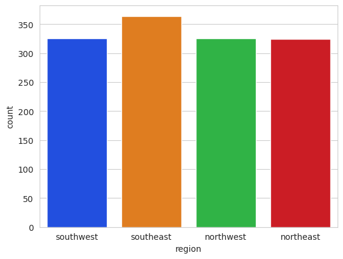

```python
sns.set_style("whitegrid")
sns.countplot(df, x="region", hue = "region")
```

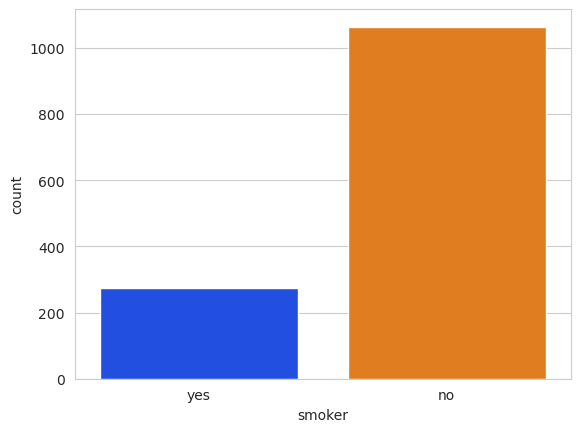

```python
sns.set_style("whitegrid")
sns.countplot(df, x='smoker', hue = "smoker")
```

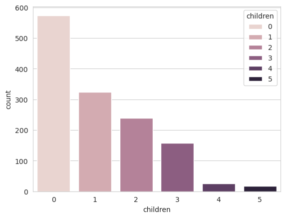

```python
sns.set_style("whitegrid")
sns.countplot(df, x="children", hue = "children")
```

So far, it appears that smoking has the highest effect on insurance charges but everything else plays a small factor as well.

(b) Fit a multiple linear regression model. How much variance in the medical costs(charges) does this variable- bmi explain?

```python
df["smoker"] = df["smoker"].replace({"yes": 1, "no":0})
df["region"] = df["region"].replace({"southwest" : 0, "southeast" : 1, "northwest" : 2, "northeast" : 3})
df["sex"] = df["sex"].replace({"female" : 0, "male" : 1})
```

```python
df.dtypes
```

```
age           int64
sex           int64
bmi         float64
children      int64
smoker        int64
region        int64
charges     float64
dtype: object
```

```python
df.head()
```

|  | age | sex | bmi | children | smoker | region | charges |
| --- | --- | --- | --- | --- | --- | --- | --- |
| 0 | 19 | 0 | 27.900 | 0 | 1 | 0 | 16884.92400 |
| 1 | 18 | 1 | 33.770 | 1 | 0 | 1 | 1725.55230 |
| 2 | 28 | 1 | 33.000 | 3 | 0 | 1 | 4449.46200 |
| 3 | 33 | 1 | 22.705 | 0 | 0 | 2 | 21984.47061 |
| 4 | 32 | 1 | 28.880 | 0 | 0 | 2 | 3866.85520 |

```python
df.dtypes
```

```
age           int64
sex           int64
bmi         float64
children      int64
smoker        int64
region        int64
charges     float64
dtype: object
```

```python
X7 = df[["age","bmi","children", "smoker", "region", "sex"]]
X7 = sm.add_constant(X7)
y7 = df["charges"]

model = sm.OLS(y7, X7).fit()
print(model.summary())
```

```
                            OLS Regression Results
==============================================================================
Dep. Variable:                charges   R-squared:                       0.751
Model:                            OLS   Adj. R-squared:                  0.750
Method:                 Least Squares   F-statistic:                     668.1
Date:                Mon, 01 Dec 2025   Prob (F-statistic):               0.00
Time:                        01:56:07   Log-Likelihood:                -13548.
No. Observations:                1338   AIC:                         2.711e+04
Df Residuals:                    1331   BIC:                         2.715e+04
Df Model:                           6
Covariance Type:            nonrobust
==============================================================================
                 coef    std err          t      P>|t|      [0.025      0.975]
------------------------------------------------------------------------------
const      -1.288e+04   1013.505    -12.705      0.000   -1.49e+04   -1.09e+04
age          257.2881     11.886     21.647      0.000     233.971     280.605
bmi          332.5701     27.722     11.997      0.000     278.186     386.954
children     479.3694    137.644      3.483      0.001     209.346     749.393
smoker      2.382e+04    411.843     57.839      0.000     2.3e+04    2.46e+04
region       353.6400    151.927      2.328      0.020      55.598     651.682
sex         -131.1106    332.811     -0.394      0.694    -784.001     521.780
==============================================================================
Omnibus:                      299.003   Durbin-Watson:                   2.088
Prob(Omnibus):                  0.000   Jarque-Bera (JB):              713.975
Skew:                           1.207   Prob(JB):                    9.17e-156
Kurtosis:                       5.642   Cond. No.                         315.
==============================================================================

Notes:
[1] Standard Errors assume that the covariance matrix of the errors is correctly specified.
```

I used OLS for charges becase it's not binary

(c) Evaluate the statistical assumptions in your regression analysis from part (b) by performing a basic analysis of model residuals and any unusual observations. Discuss any concerns you have about your model.

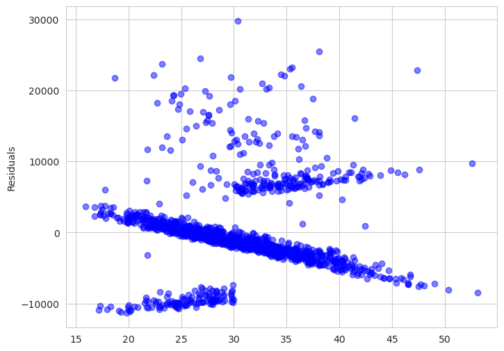

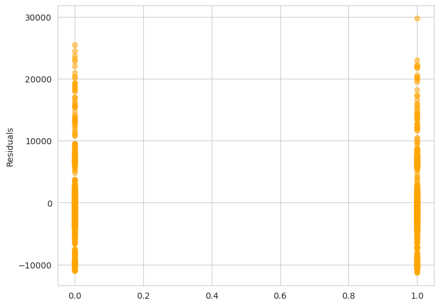

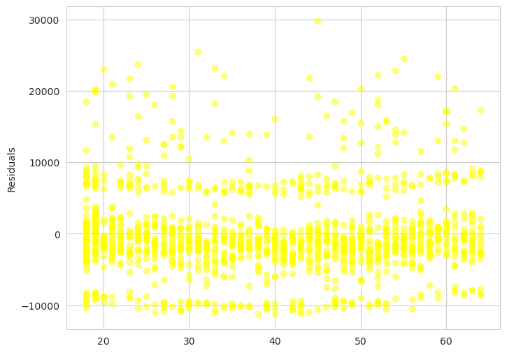

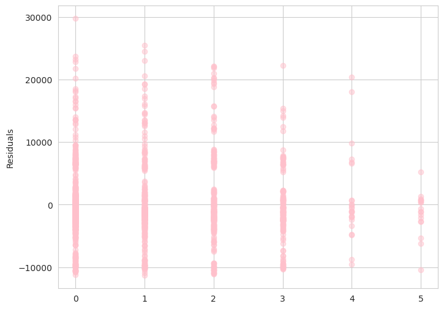

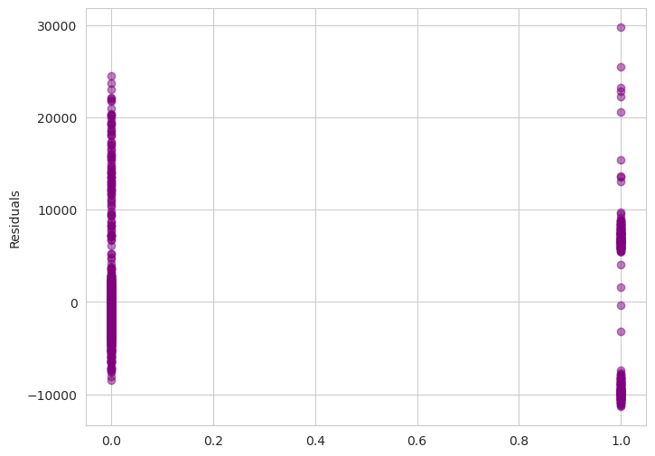

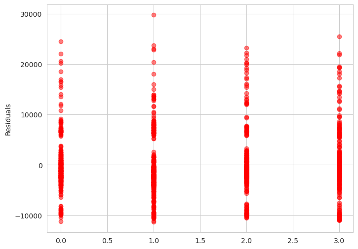

```python
fitted_vals = model.fittedvalues
residuals = model.resid

plt.figure(figsize=(8,6))
plt.scatter(df["bmi"], residuals, alpha=0.5, color="blue")
plt.ylabel("Residuals")
plt.show()

fitted_vals = model.fittedvalues
residuals = model.resid
plt.figure(figsize=(8,6))
plt.scatter(df["sex"], residuals, alpha=0.5, color="orange")
plt.ylabel("Residuals")
plt.show()

fitted_vals = model.fittedvalues
residuals = model.resid
plt.figure(figsize=(8,6))
plt.scatter(df["age"], residuals, alpha=0.5, color="yellow")
plt.ylabel("Residuals")
plt.show()


fitted_vals = model.fittedvalues
residuals = model.resid
plt.figure(figsize=(8,6))
plt.scatter(df["children"], residuals, alpha=0.5, color="pink")
plt.ylabel("Residuals")
plt.show()

fitted_vals = model.fittedvalues
residuals = model.resid
plt.figure(figsize=(8,6))
plt.scatter(df["smoker"], residuals, alpha=0.5, color="purple")
plt.ylabel("Residuals")
plt.show()

fitted_vals = model.fittedvalues
residuals = model.resid
plt.figure(figsize=(8,6))
plt.scatter(df["region"], residuals, alpha=0.5, color="red")
plt.ylabel("Residuals")
plt.show()
```

My residuals are not scattered randomly, there appears to be a pattern which isn't what we want to see when our residuals are graphed. It appears that smoking plays the biggest influence on charges.

Sources: https://www.statsmodels.org/stable/generated/statsmodels.regression.linear_model.RegressionResults.html https://pandas.pydata.org/pandas-docs/stable/reference/api/pandas.core.groupby.DataFrameGroupBy.aggregate.html https://pandas.pydata.org/pandas-docs/stable/reference/api/pandas.DataFrame.agg.html

(d) Use a stepwise model selection procedure of your choice to obtain a "best" fit model. Is the model different from the full model you fit in part (b)? If yes, how so?

```python
from mlxtend.feature_selection import SequentialFeatureSelector
X22 = df.iloc[:,0:6]
y22 = df.iloc[:,-1]
```

```python
X22.dtypes
```

```
age           int64
sex           int64
bmi         float64
children      int64
smoker        int64
region        int64
dtype: object
```

```python
y22.dtypes
```

```
dtype('float64')
```

```python
print(X22)
```

```
      age  sex     bmi  children  smoker  region
0      19    0  27.900         0       1       0
1      18    1  33.770         1       0       1
2      28    1  33.000         3       0       1
3      33    1  22.705         0       0       2
4      32    1  28.880         0       0       2
...   ...  ...     ...       ...     ...     ...
1333   50    1  30.970         3       0       2
1334   18    0  31.920         0       0       3
1335   18    0  36.850         0       0       1
1336   21    0  25.800         0       0       0
1337   61    0  29.070         0       1       2

[1338 rows x 6 columns]
```

```python
print(y22)
```

```
0       16884.92400
1        1725.55230
2        4449.46200
3       21984.47061
4        3866.85520
           ...
1333    10600.54830
1334     2205.98080
1335     1629.83350
1336     2007.94500
1337    29141.36030
Name: charges, Length: 1338, dtype: float64
```

```python
from sklearn.model_selection import train_test_split
X_train, X_test, y_train, y_test = train_test_split(X22,y22,test_size=0.3,random_state=105)
```

```python
from sklearn.ensemble import RandomForestRegressor
```

```python
forward_feature_selection2 = SequentialFeatureSelector(RandomForestRegressor(n_jobs=-1),
                                                       k_features = 6,
                                                       forward = True,
                                                       floating = False,
                                                       verbose = 2,
                                                       scoring = "r2",
                                                       cv=5).fit(X_train, y_train)
```

```
[2025-12-01 02:00:13] Features: 1/6 -- score: 0.5995010888779453
[2025-12-01 02:00:20] Features: 2/6 -- score: 0.6535935130609183
[2025-12-01 02:00:25] Features: 3/6 -- score: 0.786400358897362
[2025-12-01 02:00:29] Features: 4/6 -- score: 0.8042610146261996
[2025-12-01 02:00:31] Features: 5/6 -- score: 0.8155459653209715
[2025-12-01 02:00:32] Features: 6/6 -- score: 0.8194863851901732
```

```python
forward_feature_selection2.k_feature_idx_
```

```
(0, 1, 2, 3, 4, 5)
```

```python
forward_feature_selection2.k_feature_names_
```

```
('age', 'sex', 'bmi', 'children', 'smoker', 'region')
```

```python
forward_feature_selection.k_score_
```

```
0.7953302330731329
```

```python
pd.DataFrame.from_dict(forward_feature_selection2.get_metric_dict()).T
```

|  | feature_idx | cv_scores | avg_score | feature_names | ci_bound | std_dev | std_err |
| --- | --- | --- | --- | --- | --- | --- | --- |
| 1 | (4,) | [0.606451296886906, 0.6550148265299196, 0.6442... | 0.599501 | (smoker,) | 0.060831 | 0.047328 | 0.023664 |
| 2 | (2, 4) | [0.6457870082270332, 0.7099694522835529, 0.659... | 0.653594 | (bmi, smoker) | 0.039612 | 0.03082 | 0.01541 |
| 3 | (0, 2, 4) | [0.7509638071687117, 0.860217636832585, 0.7736... | 0.7864 | (age, bmi, smoker) | 0.049095 | 0.038197 | 0.019099 |
| 4 | (0, 2, 3, 4) | [0.7717533151292675, 0.8846075618952125, 0.782... | 0.804261 | (age, bmi, children, smoker) | 0.052665 | 0.040975 | 0.020488 |
| 5 | (0, 2, 3, 4, 5) | [0.7831709162423801, 0.8891362179940197, 0.798... | 0.815546 | (age, bmi, children, smoker, region) | 0.048647 | 0.037849 | 0.018924 |
| 6 | (0, 1, 2, 3, 4, 5) | [0.7897367312828099, 0.8954538341255522, 0.800... | 0.819486 | (age, sex, bmi, children, smoker, region) | 0.049601 | 0.038591 | 0.019296 |

This does conclude what I thought, that smoker is the most important factor in predicting charges

```python
Sources:https://www.youtube.com/watch?v=POCvLGRLDzM
https://scikit-learn.org/stable/modules/generated/sklearn.ensemble.RandomForestRegressor.html
https://www.geeksforgeeks.org/machine-learning/random-forest-regression-in-python/
```

EXTRA CREDIT (Max point: 2) : Fit a regression tree using the same covariates in your "best" fit model from part (d). Use cross validation to select the "best" tree. Compare the models from part (d) and (f) based on their performance. Which do you prefer? Be sure to justify your preference.

### Problem 4

Points: 20

The Wisconsin Breast Cancer dataset is available on the [UCI Machine Learning Repository](https://archive.ics.uci.edu/dataset/15/breast+cancer+wisconsin+original). Our goal in this problem will be to predict whether observations (i.e. tumors) are malignant or benign. We will use the original dataset in this problem.

(a) Obtain the data and load it into your programming environment by pulling it directly from the web (links provided below). (Do **not** download it and import it from a CSV file.) Give a brief description of the data.

```python
# Web location of data file
location = "http://archive.ics.uci.edu/ml/machine-learning-databases/"
dataframe = "breast-cancer-wisconsin/breast-cancer-wisconsin.data"
```

```python
webpage = (location + dataframe)

wbc_columns = ["Sample_code_number", "Clump_thickness", "Uniformity_of_cell_size", "Uniformity_of_cell_shape", "Marginal_adhesion", "Single_epithelial_cell_size", "Bare_nuclei", "Bland_chromatin", "Normal_nucleoli", "Mitoses", "Class"]

wbc_df = pd.read_csv(webpage, names=wbc_columns)
print(wbc_df)
```

```
     Sample_code_number  Clump_thickness  Uniformity_of_cell_size  \
0               1000025                5                        1
1               1002945                5                        4
2               1015425                3                        1
3               1016277                6                        8
4               1017023                4                        1
..                  ...              ...                      ...
694              776715                3                        1
695              841769                2                        1
696              888820                5                       10
697              897471                4                        8
698              897471                4                        8

     Uniformity_of_cell_shape  Marginal_adhesion  Single_epithelial_cell_size  \
0                           1                  1                            2
```

[output cut: 25 more lines]

```python
wbc_df.describe()
```

|  | Sample_code_number | Clump_thickness | Uniformity_of_cell_size | Uniformity_of_cell_shape | Marginal_adhesion | Single_epithelial_cell_size | Bland_chromatin | Normal_nucleoli | Mitoses | Class |
| --- | --- | --- | --- | --- | --- | --- | --- | --- | --- | --- |
| count | 6.990000e+02 | 699.000000 | 699.000000 | 699.000000 | 699.000000 | 699.000000 | 699.000000 | 699.000000 | 699.000000 | 699.000000 |
| mean | 1.071704e+06 | 4.417740 | 3.134478 | 3.207439 | 2.806867 | 3.216023 | 3.437768 | 2.866953 | 1.589413 | 2.689557 |
| std | 6.170957e+05 | 2.815741 | 3.051459 | 2.971913 | 2.855379 | 2.214300 | 2.438364 | 3.053634 | 1.715078 | 0.951273 |
| min | 6.163400e+04 | 1.000000 | 1.000000 | 1.000000 | 1.000000 | 1.000000 | 1.000000 | 1.000000 | 1.000000 | 2.000000 |
| 25% | 8.706885e+05 | 2.000000 | 1.000000 | 1.000000 | 1.000000 | 2.000000 | 2.000000 | 1.000000 | 1.000000 | 2.000000 |
| 50% | 1.171710e+06 | 4.000000 | 1.000000 | 1.000000 | 1.000000 | 2.000000 | 3.000000 | 1.000000 | 1.000000 | 2.000000 |
| 75% | 1.238298e+06 | 6.000000 | 5.000000 | 5.000000 | 4.000000 | 4.000000 | 5.000000 | 4.000000 | 1.000000 | 4.000000 |
| max | 1.345435e+07 | 10.000000 | 10.000000 | 10.000000 | 10.000000 | 10.000000 | 10.000000 | 10.000000 | 10.000000 | 4.000000 |

```python
wbc_df.head()
```

|  | Sample_code_number | Clump_thickness | Uniformity_of_cell_size | Uniformity_of_cell_shape | Marginal_adhesion | Single_epithelial_cell_size | Bare_nuclei | Bland_chromatin | Normal_nucleoli | Mitoses | Class |
| --- | --- | --- | --- | --- | --- | --- | --- | --- | --- | --- | --- |
| 0 | 1000025 | 5 | 1 | 1 | 1 | 2 | 1 | 3 | 1 | 1 | 2 |
| 1 | 1002945 | 5 | 4 | 4 | 5 | 7 | 10 | 3 | 2 | 1 | 2 |
| 2 | 1015425 | 3 | 1 | 1 | 1 | 2 | 2 | 3 | 1 | 1 | 2 |
| 3 | 1016277 | 6 | 8 | 8 | 1 | 3 | 4 | 3 | 7 | 1 | 2 |
| 4 | 1017023 | 4 | 1 | 1 | 3 | 2 | 1 | 3 | 1 | 1 | 2 |

```python
wbc_df.tail()
```

|  | Sample_code_number | Clump_thickness | Uniformity_of_cell_size | Uniformity_of_cell_shape | Marginal_adhesion | Single_epithelial_cell_size | Bare_nuclei | Bland_chromatin | Normal_nucleoli | Mitoses | Class |
| --- | --- | --- | --- | --- | --- | --- | --- | --- | --- | --- | --- |
| 694 | 776715 | 3 | 1 | 1 | 1 | 3 | 2 | 1 | 1 | 1 | 2 |
| 695 | 841769 | 2 | 1 | 1 | 1 | 2 | 1 | 1 | 1 | 1 | 2 |
| 696 | 888820 | 5 | 10 | 10 | 3 | 7 | 3 | 8 | 10 | 2 | 4 |
| 697 | 897471 | 4 | 8 | 6 | 4 | 3 | 4 | 10 | 6 | 1 | 4 |
| 698 | 897471 | 4 | 8 | 8 | 5 | 4 | 5 | 10 | 4 | 1 | 4 |

Sources: https://www.slingacademy.com/article/how-to-use-pandas-for-web-scraping-and-saving-data-2-examples/

(b) Investigate the data, ensuring that each variable is properly named and cast as the correct data type. Discuss any missing data.

```python
wbc_df.apply(lambda x: sum(x.isnull()), axis=0)
```

```
Sample_code_number             0
Clump_thickness                0
Uniformity_of_cell_size        0
Uniformity_of_cell_shape       0
Marginal_adhesion              0
Single_epithelial_cell_size    0
Bare_nuclei                    0
Bland_chromatin                0
Normal_nucleoli                0
Mitoses                        0
Class                          0
dtype: int64
```

```python
wbc_df.dtypes
```

```
Sample_code_number              int64
Clump_thickness                 int64
Uniformity_of_cell_size         int64
Uniformity_of_cell_shape        int64
Marginal_adhesion               int64
Single_epithelial_cell_size     int64
Bare_nuclei                    object
Bland_chromatin                 int64
Normal_nucleoli                 int64
Mitoses                         int64
Class                           int64
dtype: object
```

Some of my wbc df types are coming back as objects

```python
print(wbc_df["Bare_nuclei"])
```

```
0       1
1      10
2       2
3       4
4       1
       ..
694     2
695     1
696     3
697     4
698     5
Name: Bare_nuclei, Length: 699, dtype: object
```

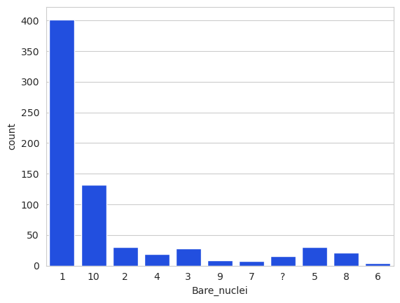

```python
sns.set_style("whitegrid")
sns.countplot(wbc_df, x='Bare_nuclei')
```

```python
wbc_df = wbc_df.astype({"Bare_nuclei" : 'int64'})
wbc_df.dtypes
```

[output not shown]

[output cut: 19 more lines]

[output not shown]

Some of my columns have question marks

```python
wbc_df["Bare_nuclei"] = wbc_df["Bare_nuclei"].replace("?", "0")
```

```python
wbc_df.dtypes
```

```
Sample_code_number              int64
Clump_thickness                 int64
Uniformity_of_cell_size         int64
Uniformity_of_cell_shape        int64
Marginal_adhesion               int64
Single_epithelial_cell_size     int64
Bare_nuclei                    object
Bland_chromatin                 int64
Normal_nucleoli                 int64
Mitoses                         int64
Class                           int64
dtype: object
```

Sources: https://stackoverflow.com/questions/64957335/replace-question-mark-in-pandas-dataframe

I used this to see how to replace my "?" vales in bare_nuceli with question marks.

(c) Split the data into a training and test set such that a random 70% of the observations are in the training set.

```python
from sklearn.linear_model import LogisticRegression
from sklearn.model_selection import train_test_split
from sklearn.metrics import classification_report, confusion_matrix
```

```python
X4 = wbc_df[['Sample_code_number', 'Uniformity_of_cell_size', 'Uniformity_of_cell_shape', 'Marginal_adhesion', 'Single_epithelial_cell_size', 'Bare_nuclei', 'Bland_chromatin' , 'Normal_nucleoli', 'Mitoses']].values
y4 = wbc_df['Class'].values
```

```python
X_train, X_test, y_train, y_test = train_test_split(X4, y4, test_size=0.3, random_state=42)

print(f"Training samples: {len(X_train)}")
print(f"Testing samples: {len(X_test)}")
```

```
Training samples: 489
Testing samples: 210
```

```python
log_reg = LogisticRegression()
log_reg.fit(X_train, y_train)

print("Coefficients:", log_reg.coef_)
print("Intercept:", log_reg.intercept_)
```

```
Coefficients: [[-5.21255824e-06  2.68474436e-01  3.16097512e-01  4.10075592e-02
   5.67861528e-03  5.53104224e-01  1.37435336e-01  8.12659878e-02
   8.63429999e-02]]
Intercept: [-0.10204737]
```

(d) Fit a ML model to predict whether tissue samples are malignant or benign. Then use your model to classify cases in your test set, which is the remaining 30% of the all the observations. Compute and discuss the resulting confusion matrix. Be sure to address which of the errors that are identified you consider most problematic in this context.

```python
y_pred = log_reg.predict(X_test)

print("Confusion Matrix:")
print(confusion_matrix(y_test, y_pred))
print("\nClassification Report:")
print(classification_report(y_test, y_pred))
```

```
Confusion Matrix:
[[136   7]
 [ 11  56]]

Classification Report:
              precision    recall  f1-score   support

           2       0.93      0.95      0.94       143
           4       0.89      0.84      0.86        67

    accuracy                           0.91       210
   macro avg       0.91      0.89      0.90       210
weighted avg       0.91      0.91      0.91       210
```

The errors I identified are that my model is that 2 = benign, 4 = malignant for class of breast cancer so precesion on benign breast cancer is 93% and 89% accurate when it comes to malignant breast cancer prediction. I don't want my model to overfit so this level of fitting is OK to me. I also had a hard time getting the Bare_nuclei data to be usable so I had any calues that were question marks replaced with 0.

Sources: logistic_regression_iris_example for training a model and logistic regression https://www.geeksforgeeks.org/machine-learning/ml-logistic-regression-using-python/

### Problem 5

Points: 10

Please answer the questions below by writing a short response.

(a) Describe three real-life applications in which **classification** might be useful. Describe the response, as well as the predictors. Is the goal in each application inference or predictions? Explain your answer.

Classification might be useful in:

1. Diagnosing heart attacks - Response: Classify patients as having a heart attack or not having a heart attack - Predictors: medical history, family history, and demographic information. The goal here is prediction, you are trying to perdict if a patient is having a heart attack or not.
2. Filtering out spam emails - Response: Classifying emails as spam or legitimate emails - Predictors: sending email address domain, grammar, spelling mistakes, flow of sentence. The goal here is prediction, you are trying to perdict if an email is spam or legitimate.
3. Loan financing - Response: Approving or denying home laons - Predictors: Credit history, downpayment information, salary, fiancing terms, coborrower or single borrower. The goal here is prediction, you are trying to perdict if a borrower will default on a loan or not.

b) Describe three real-life applications in which **regression** might be useful. Describe the response, as well as the predictors. Is the goal in each application inference or predictions? Explain your answer.

Regresion might be useful in:

1. The effects of water amount on crop yield - Response: Finding if more water yields more crops - Predictors: amount of water vs crops used. The goal here is application inference
2. How tall sons will be compared to their fathers - Response: Finding if sons will be taller or shorter then their fathers - Predictors: Son height and father height
3. Advertising vs spending revenue - Response: Finding the ideal budget for spending on ads - Predictors: Sales vs money spent on ads

(c) What are the advantages and disadvantages of a very flexible (versus a less flexible) approach for regression or classification? Under what circumstances might a more flexible approach be preferred to a less flexible approach? When might a less flexible approach be preferred?

A more flexible approach is better for trying to predict, but a less flexible approach is preffered for trying to make inferences about data. If a model is too flexible it runs the risk of overfitting the dataset.

### Problem 6

Points: 10

Suppose we have a dataset with five predictors, $X_1 =$ GPA, $X_2 =$ IQ, $X_3 =$ Gender (1 for Female, and 0 for Male), $X_4 =$ Interaction between GPA and IQ, and $X_5 =$ Interaction between GPA and Gender. Note: the data here is limited as gender was collected as a binary variable.

The response is starting salary after graduation (in thousands of dollars). Suppose we use least squares to fit the model and get $\hat{\beta}_0=50, \hat{\beta}_1=20, \hat{\beta}_2=0.07, \hat{\beta}_3=35, \hat{\beta}_4=0.01$, and $\hat{\beta}_5=-10$.

(a) Which answer is correct and why? [single choice question]

i. For a fixed value of IQ and GPA, males earn more on average than females.

ii. For a fixed value of IQ and GPA, females earn more on average than males.

iii. For a fixed value of IQ and GPA, males earn more on average than females provided that the GPA is high enough.

iv. For a fixed value of IQ and GPA, females earn more on average than males provided that the GPA is high enough.

The correct answer is iv. For a fixed value of IQ and GPA, females earn more on average than males provided that the GPA is high enough.

(b) Wite down the least square function and then predict the salary of a female with IQ of 110 and a GPA of 4.0.

```python
y = 50 + (20 * 4) + (0.07 * 110) + (35*1) + (0.01 * (4*110)) + (-10*(4*1))
print(y)
```

```
137.1
```

The salary for a a female with IQ of 110 and a GPA of 4.0 is $137,100.00

(c) True or false: Since the coefficient for the GPA/IQ interaction term is very small, there is little evidence of an interaction effect. Justify your answer.

False, a small coefficient by itself is not evidence of a interaction effect. Signifigance is determined by the p-value.

### Problem 7 - Extra Credit

Points: Max. 4

Suppose that $X_1, \ldots X_n$ form a random sample from a Poisson distribution for which the mean $\theta$ is unknown, $(\theta>0)$.

(a) Determine the MLE of $\theta$, assuming that at least one of the observed values is different from 0. Show your work.

(b) Show that the MLE of $\theta$ does not exists if every observed value is 0.

### Problem 8 - Extra Credit

Points: Max. 4

In this extra credit problem, you'll build a simple web scraper to collect and process text data. You'll write the code necessary to scrape lyrics for a desired artist. Your code should be structured such that one can easily execute your scraping functions for a given artist. There are three deliverables for this assignment:

1. A set of functions necessary for scraping the lyrics of a specific artist.
2. An example implementation of using your functions.
3. A file of example output from your notebook implementation.

The specific approach that you take to structuring your code is up to you, but the final output .csv data should have the following columns (each row is a song from an artist that you choose):

- Column 1: artist
- Column 2: album
- Column 3: song title
- Column 4: URL of song lyrics
- Column 5: song lyrics (all of the lyrics in one column)
- Column 6: number of words in the song

**Data Scraping:** The actual scraping of data should be supported by separate functions that accomplish these tasks:

1. Given an artist, identify all of their albums, songs, and links to songs.
2. Given a set of song links (from step 1), collect the lyrics to each song and store them in a data frame.

In order to do this, you'll need to understand the structure of your lyrics site. The site you use is up to you, but all of this information should be available on lyrics.com.

**Data Processing:**

Once you've scraped the data, you'll need to do some simple text analysis to generate your columns of interest (feel free to do this as part of step 2 above, the collection of lyrics for each song or as a separate step entirely). Recall you are aiming to count the number of words in each song.

**Example Implementation:**

You should demonstrate the implementation of your data scraping functions with a particular artist. To do this you can simply set an artist, and run your scraping functions. The way in which you choose to structure your functions is up to you, as long as the implementation and documentation is clear. One way in which we'll test this is changing the artist to confirm the flexibility of your implementation.

It may look something like this:

```python
# NOTE THIS CODE WILL NOT RUN
# UNTIL YOU WRITE YOUR WEB SCRAPING FUNCTIONS

# Get songs
artist = 'Adele'
all_songs = get_songs(artist)

# Get lyrics -- internally, you may want to another function in your library, such as get_lyrics()
lyrics = get_all_lyrics(songs)

# Save data -- this function should identify the name of the artist and use it in the .csv file it saves
save_lyrics(lyrics)
```

(a) Write a function to get all the songs of a particular artist.

(b) Write a function to get all the lyrics for a particular song. You may also want to write a function to get all the lyrics for a list of songs.

(c) Choose a particular artist. Get all their songs. Get all the lyrics for their songs. Process the data so that you end up with a nice, tidy data structure as described in the instructions (i.e. the six columns listed above). Write out the data to a CSV file.

(d) Produce one visualization of the data to aids in understanding the distribution of words in songs for a particular artist. Comment on what you find.